# **Introducción a la Modelación de Datos Espaciales usando R**

```r
shapiro.test(residuals(reg_mco))
```

```
##
##  Shapiro-Wilk normality test
##
## data:  residuals(reg_mco)
## W = 0.84071, p-value = 2.572e-09
```

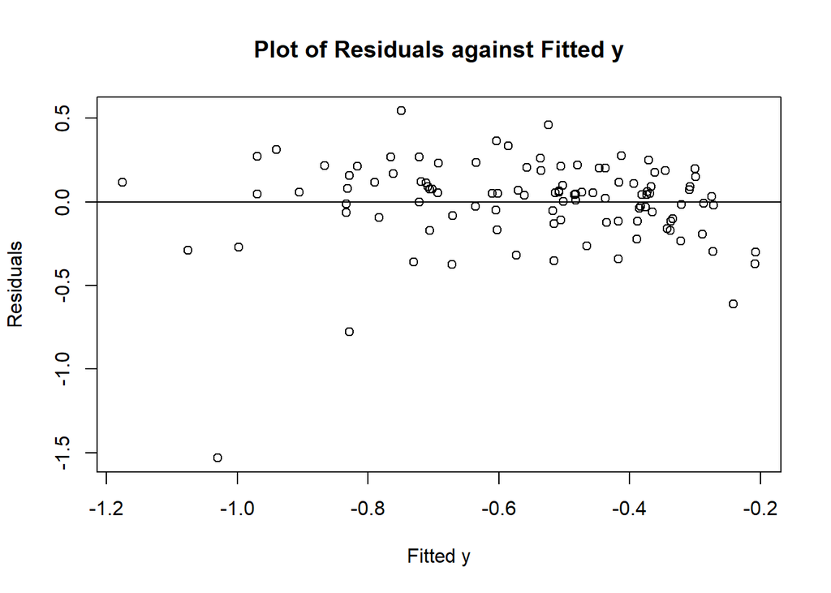

```r
# No hay normalidad en los residuos

# A partir del siguiente gráfico, estudiamos el supuesto de homocedasticidad
plot(fitted(reg_mco), residuals(reg_mco), xlab="Fitted y", ylab= "Residuals",
     main="Plot of Residuals against Fitted y")
abline(h=0)
```

```r
# Usemos una prueba formal:
bptest(reg_mco) # No se rechaza Ho (Homocedasticidad)
```

```
##
##  studentized Breusch-Pagan test
##
## data:  reg_mco
## BP = 8.1224, df = 5, p-value = 0.1496
```

```r
#----------------------------------------------#
# Se verifica la independencia de los residuos #
#----------------------------------------------#

# Test de Durbin-Watson para autocorrelación de los errores
dwtest(reg_mco)
```

```
##
##  Durbin-Watson test
##
## data:  reg_mco
## DW = 1.9929, p-value = 0.4403
## alternative hypothesis: true autocorrelation is greater than 0
```

```r
# Véase la información de los pesos de la matriz
names(attributes(bgQ1.gal))  # Nombres de los atributos
```

```
## [1] "names"       "class"       "region.id"   "call"        "zero.policy"
```

```r
card(bgQ1.gal$neighbours)    # Número de vecinos para cada observación
```

```
##   [1]  6  4  6  8  6  7  7  4  4  3  6  3  4  5  5  6  7  4  3  5  6  5  4  5  8
##  [26]  8  9  6  6  5  8  6  5  7  8  5  1  3  6  2  4  4  5  4  7  5  8  3  6  6
##  [51]  8  6  7  7  3  4  6  5  3  3  7  6  6  5  8  6  4  6  4  6  4  3  5  5  2
##  [76]  6  8  7  3  3  4  4  6  6  5  6  7  6  8  6  5  6  5  8  3  2  8 10  4  4
## [101]  7  4  6  6  4  8
```

```r
range(card(bgQ1.gal$neighbours))  # Rango (número de vecinos)
```

```
## [1]  1 10
```

```r
1/rev(range(card(bgQ1.gal$neighbours))) # Rango (pesos)
```

```
## [1] 0.1 1.0
```

```r
summary(bgQ1.gal, zero.policy=T)   # Resumen
```

```
## Characteristics of weights list object:
## Neighbour list object:
## Number of regions: 106
## Number of nonzero links: 572
## Percentage nonzero weights: 5.09078
## Average number of links: 5.396226
## Link number distribution:
##
##  1  2  3  4  5  6  7  8  9 10
##  1  3 12 19 17 28 11 13  1  1
## 1 least connected region:
## 37 with 1 link
## 1 most connected region:
## 98 with 10 links
##
## Weights style: W
## Weights constants summary:
##     n    nn  S0       S1       S2
## W 106 11236 106 43.06115 433.7732
```

```r
moran.test(reg_mco$residuals, bgQ1.gal, alternative="two.sided", zero.policy=T)
```

```
##
##  Moran I test under randomisation
##
## data:  reg_mco$residuals
## weights: bgQ1.gal
##
## Moran I statistic standard deviate = 1.8613, p-value = 0.06271
## alternative hypothesis: two.sided
## sample estimates:
## Moran I statistic       Expectation          Variance
##       0.096573547      -0.009523810       0.003249357
```

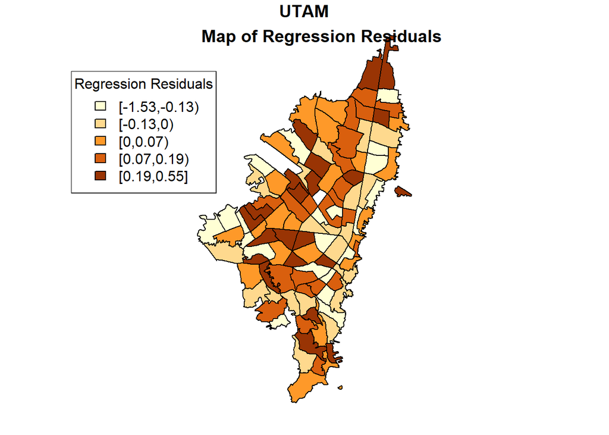

```r
# Seleccionar la paleta
colors <- brewer.pal(5, "YlOrBr")
color.cat.reg<-classIntervals(reg_mco$residuals, n=5, style="quantile", dataPrecision=2)
colcode <- findColours(color.cat.reg, colors)

## Figura
par(mfrow=c(1,1))
plot(bg_data[c("UTAM", "geometry")], col=colcode)
title('Map of Regression Residuals')
legend('topleft', legend=c(names(attr(colcode, 'table'))), fill=c(attr(colcode, 'palette')),
       title='Regression Residuals')
```

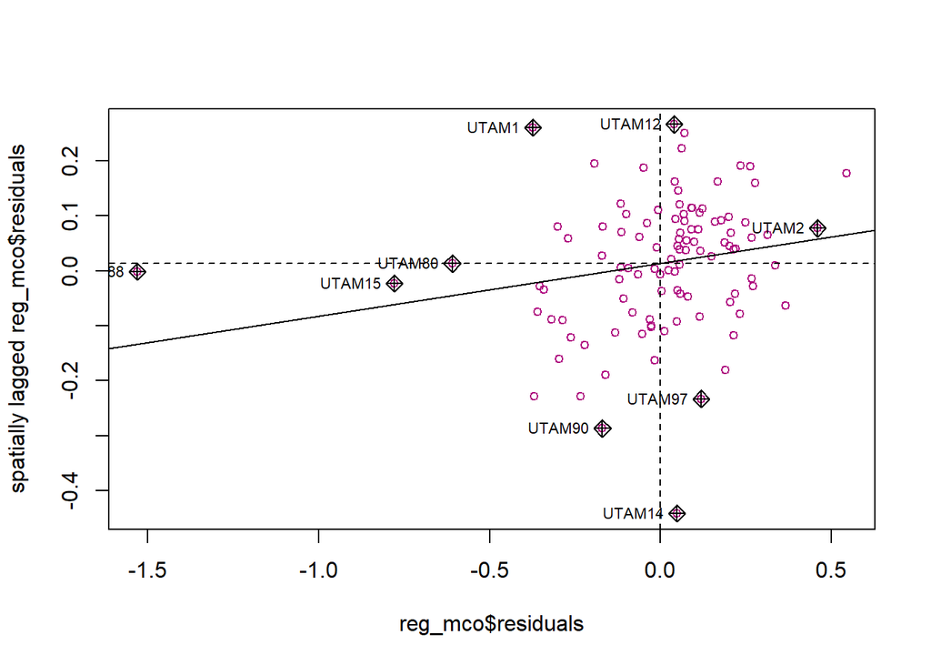

```r
moran.plot(reg_mco$residuals, bgQ1.gal, zero.policy=T, labels=as.character(bg.df$UTAM),
           xlab=NULL, ylab=NULL, type="p", col="#AE017E",
           cex=0.8, pch=1)
```

## 5.2 Modelo espacial autorregresivo (SAR) - Spillovers o efectos derramamiento

- Incorpora dependencia espacial agregando un “rezago espacial” a la variable dependiente en el lado derecho de la ecuación de regresión.
- Trata la correlación espacial como un proceso o efecto de interés.
  - Los valores de $y$ en un área están directamente influenciados por los valores de $y$ encontrados en áreas vecinas.
  - Depende de cómo definimos el vecindario.

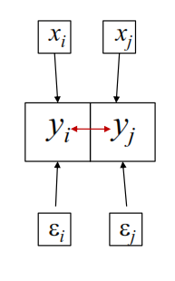

$$\boldsymbol{y}= \rho \boldsymbol{Wy} + \boldsymbol{X} \beta +
\boldsymbol{\varepsilon} \\
[\boldsymbol{I} - \boldsymbol{W}\rho]\boldsymbol{y} = \boldsymbol{X}
\beta + \boldsymbol{\varepsilon} \\
\boldsymbol{y} = [\boldsymbol{I} -
\boldsymbol{W}\rho]^{-1}\boldsymbol{X} \beta + [\boldsymbol{I} -
\boldsymbol{W}\rho]^{-1}\boldsymbol{\varepsilon}$$

- Efectos marginales son:

$$\frac{\partial \boldsymbol{y}}{\partial \boldsymbol{X}} =
[\boldsymbol{I} - \boldsymbol{W}\rho]^{-1}\boldsymbol{I}\beta$$

- De esta expresión se descompone el efecto en directo, total e indirecto.

$$\overline{M_{tot}}=n^{-1}i^{'}V(\boldsymbol{W})\beta i \\
\overline{M_{dir}}=n^{-1}tr(V(\boldsymbol{W}))\beta \\
\overline{M_{indir}}=\overline{M_{tot}}-\overline{M_{dir}}$$

- Se estima por el método de Máxima Verosimilitud.

```r
bg.lag.eig <- spatialreg::lagsarlm(lograte ~  mean_size + minor + elder
                       + ingresos_bajos + higher,
                       data=bg_data2, bgQ1.gal, method="eigen", quiet=FALSE)
```

```
##
## Spatial lag model
## Jacobian calculated using neighbourhood matrix eigenvalues
## Computing eigenvalues ...
##
## rho:  -0.5958876     function value:  -25.0674
## rho:  0.01368723     function value:  -5.769609
## rho:  0.3904252  function value:  -1.355681
## rho:  0.4917973  function value:  -1.591553
## rho:  0.4015021  function value:  -1.347294
## rho:  0.4070488  function value:  -1.346123
## rho:  0.4074864  function value:  -1.346118
## rho:  0.4074626  function value:  -1.346118
## rho:  0.4074621  function value:  -1.346118
## rho:  0.4074621  function value:  -1.346118
## rho:  0.4074621  function value:  -1.346118
## rho:  0.4074621  function value:  -1.346118
```

```r
summary(bg.lag.eig)
```

```
##
## Call:spatialreg::lagsarlm(formula = lograte ~ mean_size + minor +
##     elder + ingresos_bajos + higher, data = bg_data2, listw = bgQ1.gal,
##     method = "eigen", quiet = FALSE)
##
## Residuals:
##       Min        1Q    Median        3Q       Max
## -1.482950 -0.081033  0.035159  0.140463  0.419606
##
## Type: lag
## Coefficients: (asymptotic standard errors)
##                   Estimate  Std. Error z value  Pr(>|z|)
## (Intercept)     0.21354437  0.41650967  0.5127 0.6081614
## mean_size       0.19246585  0.10927643  1.7613 0.0781919
## minor          -0.02757574  0.00991046 -2.7825 0.0053944
## elder          -0.03052110  0.00785987 -3.8832 0.0001031
## ingresos_bajos -0.00060049  0.00294590 -0.2038 0.8384800
## higher         -0.00613477  0.00394135 -1.5565 0.1195860
##
## Rho: 0.40746, LR test value: 9.4278, p-value: 0.0021372
## Asymptotic standard error: 0.11059
##     z-value: 3.6844, p-value: 0.00022926
## Wald statistic: 13.575, p-value: 0.00022926
##
## Log likelihood: -1.346118 for lag model
## ML residual variance (sigma squared): 0.057906, (sigma: 0.24064)
## Number of observations: 106
## Number of parameters estimated: 8
## AIC: 18.692, (AIC for lm: 26.12)
## LM test for residual autocorrelation
## test value: 6.9993, p-value: 0.0081543
```

```r
bg.lag.eig.imp <- impacts(bg.lag.eig, listw = bgQ1.gal, R = 999)
summary(bg.lag.eig.imp, zstats = TRUE, short = TRUE)
```

```
## Impact measures (lag, exact):
##                       Direct      Indirect        Total
## mean_size       0.2001442209  0.1246718648  0.324816086
## minor          -0.0286758698 -0.0178624901 -0.046538360
## elder          -0.0317387290 -0.0197703762 -0.051509105
## ingresos_bajos -0.0006244422 -0.0003889714 -0.001013414
## higher         -0.0063795156 -0.0039738650 -0.010353381
## ========================================================
## Simulation results ( variance matrix):
## ========================================================
## Simulated standard errors
##                     Direct    Indirect       Total
## mean_size      0.113925379 0.104429475 0.204104295
## minor          0.010109015 0.011954862 0.019818258
## elder          0.008311396 0.012338188 0.018008576
## ingresos_bajos 0.003148305 0.002457731 0.005437567
## higher         0.004207585 0.003702133 0.007361947
##
## Simulated z-values:
##                    Direct   Indirect      Total
## mean_size       1.7783551  1.2938430  1.6546204
## minor          -2.8585080 -1.6331057 -2.4432144
## elder          -3.8079706 -1.7283582 -2.9416184
## ingresos_bajos -0.1899589 -0.1640212 -0.1841207
## higher         -1.5233142 -1.1173912 -1.4325293
##
## Simulated p-values:
##                Direct     Indirect Total
## mean_size      0.07534555 0.195720 0.098002
## minor          0.00425638 0.102447 0.014557
## elder          0.00014011 0.083924 0.003265
## ingresos_bajos 0.84934131 0.869714 0.853919
## higher         0.12768012 0.263827 0.151992
```

## 5.3 Modelo de error espacial (SEM) - Heterogeneidad espacial u omisión de variables

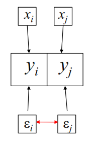

$$\boldsymbol{y}= \boldsymbol{X} \beta + \boldsymbol{u} \\$$

$$\boldsymbol{u} = \lambda \boldsymbol{Wu} + \boldsymbol{\varepsilon} \\
\boldsymbol{u} = [\boldsymbol{I} -
\boldsymbol{W}\lambda]^{-1}\boldsymbol{\varepsilon}$$

- Reemplazo en estructural,

$$\boldsymbol{y}= \boldsymbol{X} \beta + [\boldsymbol{I} -
\boldsymbol{W}\lambda]^{-1}\boldsymbol{\varepsilon} \\$$

- Efectos marginales son:

$$\frac{\partial \boldsymbol{y}}{\partial \boldsymbol{X}} =
\boldsymbol{I}\beta$$

- Se estima por el método de Máxima Verosimilitud.

```r
bg.err.eig <- spatialreg::errorsarlm(lograte ~  mean_size + minor + elder
                                     + ingresos_bajos + higher,
                         data=bg_data2, bgQ1.gal, method="eigen", quiet=FALSE)
```

```
##
## Spatial autoregressive error model
##
## Jacobian calculated using neighbourhood matrix eigenvalues
## Computing eigenvalues ...
##
## lambda: -0.5958876  function: -17.91327  Jacobian: -3.365133  SSE: 8.16662
## lambda: 0.01368723  function: -5.923133  Jacobian: -0.001910969  SSE: 6.939871
## lambda: 0.3904252  function: -4.765347  Jacobian: -1.760447  SSE: 6.568321
## lambda: 0.2933745  function: -4.577125  Jacobian: -0.9550024  SSE: 6.645261
## lambda: 0.2877932  function: -4.576575  Jacobian: -0.9170792  SSE: 6.649949
## lambda: 0.2878365  function: -4.576575  Jacobian: -0.9173701  SSE: 6.649912
## lambda: 0.287844  function: -4.576575  Jacobian: -0.9174209  SSE: 6.649906
## lambda: 0.287844  function: -4.576575  Jacobian: -0.9174208  SSE: 6.649906
## lambda: 0.2878437  function: -4.576575  Jacobian: -0.9174187  SSE: 6.649906
## lambda: 0.2878439  function: -4.576575  Jacobian: -0.91742  SSE: 6.649906
## lambda: 0.287844  function: -4.576575  Jacobian: -0.9174205  SSE: 6.649906
## lambda: 0.287844  function: -4.576575  Jacobian: -0.9174207  SSE: 6.649906
## lambda: 0.287844  function: -4.576575  Jacobian: -0.9174208  SSE: 6.649906
```

```r
summary(bg.err.eig)
```

```
##
## Call:spatialreg::errorsarlm(formula = lograte ~ mean_size + minor +
##     elder + ingresos_bajos + higher, data = bg_data2, listw = bgQ1.gal,
##     method = "eigen", quiet = FALSE)
##
## Residuals:
##       Min        1Q    Median        3Q       Max
## -1.555176 -0.095157  0.044075  0.137825  0.479638
##
## Type: error
## Coefficients: (asymptotic standard errors)
##                   Estimate  Std. Error z value  Pr(>|z|)
## (Intercept)     0.06399384  0.46385408  0.1380   0.89027
## mean_size       0.18190008  0.11565602  1.5728   0.11577
## minor          -0.02592214  0.01040386 -2.4916   0.01272
## elder          -0.03204013  0.00819700 -3.9088 9.277e-05
## ingresos_bajos -0.00079711  0.00340545 -0.2341   0.81493
## higher         -0.00809784  0.00446985 -1.8117   0.07004
##
## Lambda: 0.28784, LR test value: 2.9669, p-value: 0.084987
## Asymptotic standard error: 0.13187
##     z-value: 2.1828, p-value: 0.029051
## Wald statistic: 4.7646, p-value: 0.029051
##
## Log likelihood: -4.576575 for error model
## ML residual variance (sigma squared): 0.062735, (sigma: 0.25047)
## Number of observations: 106
## Number of parameters estimated: 8
## AIC: 25.153, (AIC for lm: 26.12)
```

```r
stargazer(reg_mco, bg.lag.eig, bg.err.eig, type = "html", title="Results", align=TRUE)
```

[output not shown]